# Ford GoBike Trip Data Exploration

## Preliminary Wrangling

This dataset includes 183412 records of trips taken with a bike sharing service around the San Francisco Bay area during the month of February 2019. The dataset includes 16 features of these trips, including the duration, start and end timestamp, start and end station, coordinates of these stations, and some features about the users such as the birth year, gender, and the user type. In this notebook, we start with the exploration of the data in order for us to get a strong understanding of the data. Our exploration will be on three segments. first, univariate eploration, Where we determine our feaatures of interest and explore each of them individually. Second, bivariate exploration, where we look into the relationships between our features of interest. Finally, multivariate exploration, Where we look into the relationships between three or more of our features of interest.

```python
# import all packages and set plots to be embedded inline
import numpy as np
import pandas as pd
import matplotlib.pyplot as plt
import seaborn as sb

%matplotlib inline
```

```python
#load dataset
df = pd.read_csv('201902-fordgobike-tripdata.csv')
#show firat few rows of the dataset
df.head()
```

|  | duration_sec | start_time | end_time | start_station_id | start_station_name | start_station_latitude | start_station_longitude | end_station_id | end_station_name | end_station_latitude | end_station_longitude | bike_id | user_type | member_birth_year | member_gender | bike_share_for_all_trip |
| --- | --- | --- | --- | --- | --- | --- | --- | --- | --- | --- | --- | --- | --- | --- | --- | --- |
| 0 | 52185 | 2019-02-28 17:32:10.1450 | 2019-03-01 08:01:55.9750 | 21.0 | Montgomery St BART Station (Market St at 2nd St) | 37.789625 | -122.400811 | 13.0 | Commercial St at Montgomery St | 37.794231 | -122.402923 | 4902 | Customer | 1984.0 | Male | No |
| 1 | 42521 | 2019-02-28 18:53:21.7890 | 2019-03-01 06:42:03.0560 | 23.0 | The Embarcadero at Steuart St | 37.791464 | -122.391034 | 81.0 | Berry St at 4th St | 37.775880 | -122.393170 | 2535 | Customer | NaN | NaN | No |
| 2 | 61854 | 2019-02-28 12:13:13.2180 | 2019-03-01 05:24:08.1460 | 86.0 | Market St at Dolores St | 37.769305 | -122.426826 | 3.0 | Powell St BART Station (Market St at 4th St) | 37.786375 | -122.404904 | 5905 | Customer | 1972.0 | Male | No |
| 3 | 36490 | 2019-02-28 17:54:26.0100 | 2019-03-01 04:02:36.8420 | 375.0 | Grove St at Masonic Ave | 37.774836 | -122.446546 | 70.0 | Central Ave at Fell St | 37.773311 | -122.444293 | 6638 | Subscriber | 1989.0 | Other | No |
| 4 | 1585 | 2019-02-28 23:54:18.5490 | 2019-03-01 00:20:44.0740 | 7.0 | Frank H Ogawa Plaza | 37.804562 | -122.271738 | 222.0 | 10th Ave at E 15th St | 37.792714 | -122.248780 | 4898 | Subscriber | 1974.0 | Male | Yes |

```python
# show the shape of the dataset
df.shape
```

```
(183412, 16)
```

```python
# Let's see some info about our features
df.info()
```

```
<class 'pandas.core.frame.DataFrame'>
RangeIndex: 183412 entries, 0 to 183411
Data columns (total 16 columns):
 #   Column                   Non-Null Count   Dtype
---  ------                   --------------   -----
 0   duration_sec             183412 non-null  int64
 1   start_time               183412 non-null  object
 2   end_time                 183412 non-null  object
 3   start_station_id         183215 non-null  float64
 4   start_station_name       183215 non-null  object
 5   start_station_latitude   183412 non-null  float64
 6   start_station_longitude  183412 non-null  float64
 7   end_station_id           183215 non-null  float64
 8   end_station_name         183215 non-null  object
 9   end_station_latitude     183412 non-null  float64
 10  end_station_longitude    183412 non-null  float64
 11  bike_id                  183412 non-null  int64
 12  user_type                183412 non-null  object
 13  member_birth_year        175147 non-null  float64
 14  member_gender            175147 non-null  object
 15  bike_share_for_all_trip  183412 non-null  object
dtypes: float64(7), int64(2), object(7)
memory usage: 22.4+ MB
```

```python
#check the null values in each feature
df.isnull().sum()
```

```
duration_sec                  0
start_time                    0
end_time                      0
start_station_id            197
start_station_name          197
start_station_latitude        0
start_station_longitude       0
end_station_id              197
end_station_name            197
end_station_latitude          0
end_station_longitude         0
bike_id                       0
user_type                     0
member_birth_year          8265
member_gender              8265
bike_share_for_all_trip       0
dtype: int64
```

```python
df.dropna(axis=0,inplace=True)
df.isnull().sum()
```

```
duration_sec               0
start_time                 0
end_time                   0
start_station_id           0
start_station_name         0
start_station_latitude     0
start_station_longitude    0
end_station_id             0
end_station_name           0
end_station_latitude       0
end_station_longitude      0
bike_id                    0
user_type                  0
member_birth_year          0
member_gender              0
bike_share_for_all_trip    0
dtype: int64
```

```python
df.info()
```

```
<class 'pandas.core.frame.DataFrame'>
Int64Index: 174952 entries, 0 to 183411
Data columns (total 16 columns):
 #   Column                   Non-Null Count   Dtype
---  ------                   --------------   -----
 0   duration_sec             174952 non-null  int64
 1   start_time               174952 non-null  object
 2   end_time                 174952 non-null  object
 3   start_station_id         174952 non-null  float64
 4   start_station_name       174952 non-null  object
 5   start_station_latitude   174952 non-null  float64
 6   start_station_longitude  174952 non-null  float64
 7   end_station_id           174952 non-null  float64
 8   end_station_name         174952 non-null  object
 9   end_station_latitude     174952 non-null  float64
 10  end_station_longitude    174952 non-null  float64
 11  bike_id                  174952 non-null  int64
 12  user_type                174952 non-null  object
 13  member_birth_year        174952 non-null  float64
 14  member_gender            174952 non-null  object
 15  bike_share_for_all_trip  174952 non-null  object
dtypes: float64(7), int64(2), object(7)
memory usage: 22.7+ MB
```

```python
# check how many user types are in the dataset
df['user_type'].unique()
```

```
array(['Customer', 'Subscriber'], dtype=object)
```

```python
# check for duplicated rows
df.duplicated().sum()
```

```
0
```

```python
# Show all the column names
df.columns
```

```
Index(['duration_sec', 'start_time', 'end_time', 'start_station_id',
       'start_station_name', 'start_station_latitude',
       'start_station_longitude', 'end_station_id', 'end_station_name',
       'end_station_latitude', 'end_station_longitude', 'bike_id', 'user_type',
       'member_birth_year', 'member_gender', 'bike_share_for_all_trip'],
      dtype='object')
```

```python
# check how many values in each user type
df['user_type'].value_counts()
```

```
Subscriber    158386
Customer       16566
Name: user_type, dtype: int64
```

### What is the structure of your dataset?

There are 183412 instances in the dataset with 16 features ('duration_sec', 'start_time', 'end_time', 'start_station_id', 'start_station_name', 'start_station_latitude', 'start_station_longitude', 'end_station_id', 'end_station_name', 'end_station_latitude', 'end_station_longitude', 'bike_id', 'user_type', 'member_birth_year', 'member_gender', 'bike_share_for_all_trip').

Most variables are numeric in nature, but the variables start_station_name, end_station_name, user_type and member_gender are qualitative nominal variables.

### What is/are the main feature(s) of interest in your dataset?

I am interested in finding the features that would best predict the duration of the trip.

### What features in the dataset do you think will help support your investigation into your feature(s) of interest?

The features that would be expected to have an effect on the duration of the trip are the user type, member gender, time of the day and member birth year.

## Univariate Exploration

> In this section, investigate distributions of individual variables. If you see unusual points or outliers, take a deeper look to clean things up and prepare yourself to look at relationships between variables.

```python
# store the value counts in type_count variable
type_count = df['user_type'].value_counts()
# store the descending order indexes of the type count in type_order variable
type_order = type_count.index
# store the total number of users in n_users
n_users = df['user_type'].value_counts().sum()
# Top user type in terms of value counts
max_type_count = type_count[0]
# proportion of the top type
max_prop = max_type_count / n_users
print(max_prop)
```

```
0.9053111710640633
```

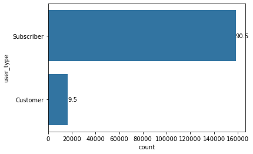

```python
base_color = sb.color_palette()[0]
sb.countplot(data = df, y ='user_type',color= base_color,order = type_order)

# iterate to annotate the proportion of each bar
for i in range (type_count.shape[0]):
    count = type_count[i]
    pct_string = '{:0.1f}'.format(100*count/n_users)

    plt.text(count+1,i, pct_string, va='center')
```

We can see that 90.5% of our users for the month of February 2019 are subscribers to the service, while the remaining 9.5% are one time customers.

```python
#creat a new dataframe including the gender of the members without the null values
gender = df[['member_gender','duration_sec']].dropna(axis=0)
```

```python
#check for null values
gender.isnull().sum()
```

```
member_gender    0
duration_sec     0
dtype: int64
```

```python
# value counts for each gender
gen_count = gender['member_gender'].value_counts()
# descending order of the genders
gen_order = gen_count.index
# total number of the members in the dataset
n_members = gender['member_gender'].value_counts().sum()
# top gender in value counts
max_gen_count = gen_count[0]
# proportion of the top gender from the total
max_prop = max_gen_count / n_members
print(max_prop)
```

```
0.7459188806072523
```

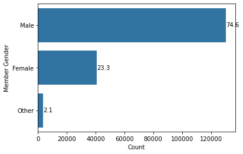

```python
# show bar chart with the proportion of each gender
sb.countplot(data = gender, y = 'member_gender' ,color= base_color,order = gen_order)
# iterate to show the proportion of each gender
for i in range (gen_count.shape[0]):
    count = gen_count[i]
    pct_string = '{:0.1f}'.format(100*count/n_members)

    plt.text(count+1,i, pct_string, va='center')
plt.ylabel('Member Gender')
plt.xlabel('Count');
```

We can see from our chart that 74.6% of our users are males, 23.3% are females, and 2.1% of the users are registered as 'other'.

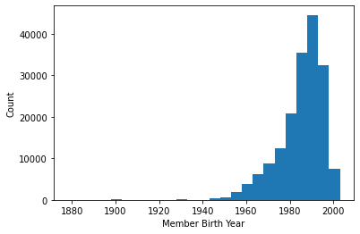

```python
# set the bins for the histogram of birth year
bins = np.arange(df['member_birth_year'].min(), df['member_birth_year'].max()+5, 5)
# show a histogram of the distribution of birth year in the dataset
plt.hist(data=df, x='member_birth_year',bins=bins);
# set axis labels
plt.xlabel('Member Birth Year')
plt.ylabel('Count');
```

We can see the the distribution of birth year is left skewed and the highest bins seem to be around 1990. However, the minumum value does not seem to make sense, as it's 1880, particuarily 1878. This would be practically impossible. So in the next cell we'll look into a more realistic range between 1930 and the maximum birth year value.

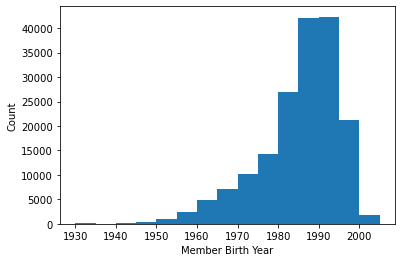

```python
# set the bins with the size of 5 years
bins = np.arange(1930, df['member_birth_year'].max()+5, 5)
# show the distribution as a histogram
plt.hist(data=df, x='member_birth_year',bins=bins);
# set the axis labels
plt.xlabel('Member Birth Year')
plt.ylabel('Count');
```

We can see from the figure that most of our users were born between 1970 and 2000. With the peak around 1990.

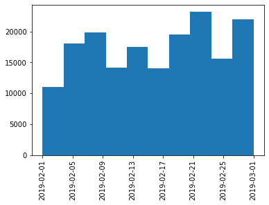

```python
# change the datatype of the timestamp to datetime
df['start_time'] = pd.to_datetime(df['start_time'])
# show the distribution of the start time
plt.hist(data=df, x='start_time');
plt.xticks(rotation=90);
```

The distribution of the start time is not insightful due to the structure of the timestamp. What we need is to extract the hour of the day from the timestamp and creat a new feature with the start and end hour. Then plot the distribution of the start and end hour.

```python
# import necessary packages to extract the hour
import datetime as dt
# extract the hour from the timestamp
df['start_hour'] = pd.to_datetime(df['start_time'], format='%H:%M').dt.hour
```

```python
df.info()
```

```
<class 'pandas.core.frame.DataFrame'>
Int64Index: 174952 entries, 0 to 183411
Data columns (total 17 columns):
 #   Column                   Non-Null Count   Dtype
---  ------                   --------------   -----
 0   duration_sec             174952 non-null  int64
 1   start_time               174952 non-null  datetime64[ns]
 2   end_time                 174952 non-null  object
 3   start_station_id         174952 non-null  float64
 4   start_station_name       174952 non-null  object
 5   start_station_latitude   174952 non-null  float64
 6   start_station_longitude  174952 non-null  float64
 7   end_station_id           174952 non-null  float64
 8   end_station_name         174952 non-null  object
 9   end_station_latitude     174952 non-null  float64
 10  end_station_longitude    174952 non-null  float64
 11  bike_id                  174952 non-null  int64
 12  user_type                174952 non-null  object
 13  member_birth_year        174952 non-null  float64
 14  member_gender            174952 non-null  object
 15  bike_share_for_all_trip  174952 non-null  object
 16  start_hour               174952 non-null  int64
dtypes: datetime64[ns](1), float64(7), int64(3), object(6)
memory usage: 29.0+ MB
```

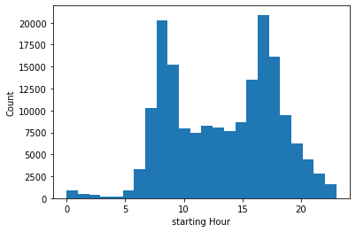

```python
# show the distribution in a histogram with a bin for each hour
plt.hist(data=df, x='start_hour',bins=24);
# set the labels
plt.xlabel('starting Hour')
plt.ylabel('Count');
```

We can see from the histogram that it's a bimodal distribution with the highest counts at 8am and 5pm. This suggests that a lot of our users use the service to commute from and to work.

```python
#extract the hour from the timestamp
df['end_hour'] = pd.to_datetime(df['end_time']).dt.hour
df.info()
```

```
<class 'pandas.core.frame.DataFrame'>
Int64Index: 174952 entries, 0 to 183411
Data columns (total 18 columns):
 #   Column                   Non-Null Count   Dtype
---  ------                   --------------   -----
 0   duration_sec             174952 non-null  int64
 1   start_time               174952 non-null  datetime64[ns]
 2   end_time                 174952 non-null  object
 3   start_station_id         174952 non-null  float64
 4   start_station_name       174952 non-null  object
 5   start_station_latitude   174952 non-null  float64
 6   start_station_longitude  174952 non-null  float64
 7   end_station_id           174952 non-null  float64
 8   end_station_name         174952 non-null  object
 9   end_station_latitude     174952 non-null  float64
 10  end_station_longitude    174952 non-null  float64
 11  bike_id                  174952 non-null  int64
 12  user_type                174952 non-null  object
 13  member_birth_year        174952 non-null  float64
 14  member_gender            174952 non-null  object
 15  bike_share_for_all_trip  174952 non-null  object
 16  start_hour               174952 non-null  int64
 17  end_hour                 174952 non-null  int64
dtypes: datetime64[ns](1), float64(7), int64(4), object(6)
memory usage: 30.4+ MB
```

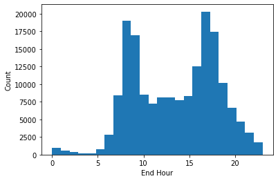

```python
# Show the distribution of the trip end hour
plt.hist(data=df, x='end_hour',bins=24);
# set axis labels
plt.xlabel('End Hour')
plt.ylabel('Count');
```

We can see that the distribution of the end hour is also bimodal with the highest bins around the same hours as the start hour.

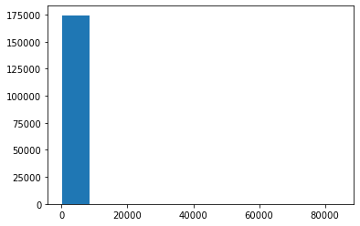

```python
# plot the distribution of the duration
plt.hist(data=df, x='duration_sec');
```

The distribution shows that most of the durations lie between 0 and 10000 seconds. However, the figure is not insightful as there is no distribution showing. Therefor, we need to normalize the distribution by transforming the duration to a log-type variable.

```python
df['duration_sec'].describe()
```

```
count    174952.000000
mean        704.002744
std        1642.204905
min          61.000000
25%         323.000000
50%         510.000000
75%         789.000000
max       84548.000000
Name: duration_sec, dtype: float64
```

```python
np.log10(df['duration_sec'].describe())
```

```
count    5.242919
mean     2.847574
std      3.215427
min      1.785330
25%      2.509203
50%      2.707570
75%      2.897077
max      4.927103
Name: duration_sec, dtype: float64
```

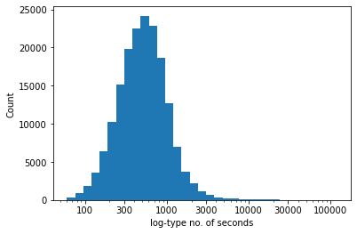

```python
# set bins according to the minimum and maximum log tranformed values
bins = 10 ** np.arange(1.78, 5+0.1, 0.1)
# set the ticks
ticks = [100, 300, 1000, 3000, 10000, 30000, 100000]
# set the ticks as strings
labels = ['{}'.format(v) for v in ticks]
# plot the duration data
plt.hist(data=df, x='duration_sec', bins=bins);
# scale the x axis to a log transformation
plt.xscale('log')
# set the labels and ticks
plt.xlabel('log-type no. of seconds')
plt.ylabel('Count')
plt.xticks(ticks, labels);
```

As we can see from the histogram, the normal distribution of the duration peaks around 500 seconds with a some outliers beyond the 10000 second mark.


## Bivariate Exploration

> In this section, investigate relationships between pairs of variables in your data. Make sure the variables that you cover here have been introduced in some fashion in the previous section (univariate exploration).

```python
df2 = df[['duration_sec','user_type','member_birth_year','member_gender','start_hour','end_hour']]
df2.dropna(axis=0,inplace=True)
df2.info()
```

```
<class 'pandas.core.frame.DataFrame'>
Int64Index: 174952 entries, 0 to 183411
Data columns (total 6 columns):
 #   Column             Non-Null Count   Dtype
---  ------             --------------   -----
 0   duration_sec       174952 non-null  int64
 1   user_type          174952 non-null  object
 2   member_birth_year  174952 non-null  float64
 3   member_gender      174952 non-null  object
 4   start_hour         174952 non-null  int64
 5   end_hour           174952 non-null  int64
dtypes: float64(1), int64(3), object(2)
memory usage: 9.3+ MB
```

```python
df2.head()
```

|  | duration_sec | user_type | member_birth_year | member_gender | start_hour | end_hour |
| --- | --- | --- | --- | --- | --- | --- |
| 0 | 52185 | Customer | 1984.0 | Male | 17 | 8 |
| 2 | 61854 | Customer | 1972.0 | Male | 12 | 5 |
| 3 | 36490 | Subscriber | 1989.0 | Other | 17 | 4 |
| 4 | 1585 | Subscriber | 1974.0 | Male | 23 | 0 |
| 5 | 1793 | Subscriber | 1959.0 | Male | 23 | 0 |

```python
# Set quantitative features
quant_vars = ['duration_sec', 'member_birth_year', 'start_hour','end_hour']
# set qualitative features
qualt_vars = ['user_type', 'member_gender']
```

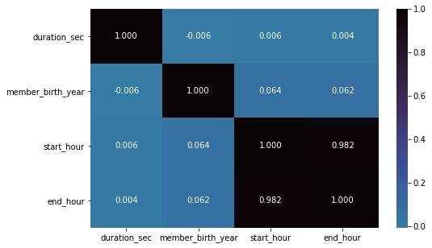

```python
# plot a heatmap with the correlation values annotations
plt.figure(figsize = [8, 5])
sb.heatmap(df2[quant_vars].corr(), annot = True, fmt = '.3f',
           cmap = 'mako_r', center = 0)
plt.show()
```

We can see from the heatmap that the quantitative features have little to no correlation with the duration. On the other hand we can see a strong positive correlation between the start and end hour.

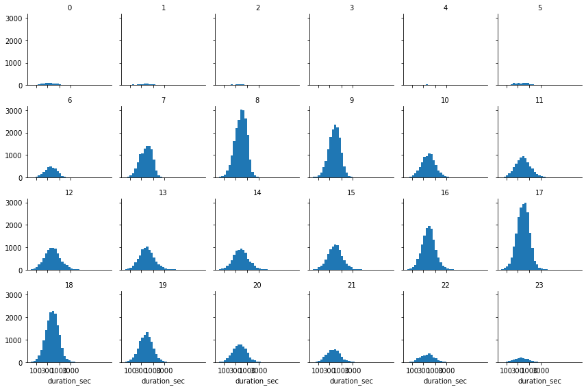

```python
# creat a facetgrid instance and set the columns of the grid to be each starting hour of the day
g = sb.FacetGrid(data = df2, col = 'start_hour', col_wrap = 6, height = 2)

ticks = [100, 300, 1000, 3000]
# set the ticks as strings
labels = ['{}'.format(v) for v in ticks]
# plot the distribution of the duration in seconds in each hour
g.map(plt.hist, 'duration_sec',
bins = 10 ** np.arange(1.78, 5+0.1, 0.1))
# scale the duration to a log-type
plt.xscale('log')
# set ticks
plt.xticks(ticks, labels);

g.set_titles('{col_name}');
```

As we've seen earlier, the hours of the start and end of the work day have the highest activity on the service. In addition, we can also notice how the start hour of the day would impact the duration of the trip. In the next cell, we'll take a closer look at the relationship between the hour of the day and the mean duration of the trip.

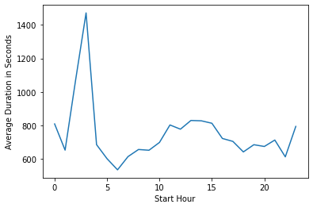

```python
# creat a dataframe with the start hour and duration features
start_df = df2[['duration_sec','start_hour']]
# get the mean duration for each hour of the day
hour_means = start_df.groupby('start_hour').mean()
hour_means = hour_means.reset_index()
# creat a line plot to visualize the change of the mean throughout the day
plt.errorbar(data=hour_means, x='start_hour', y='duration_sec')
# set the labels
plt.xlabel('Start Hour');
plt.ylabel('Average Duration in Seconds');
```

As shown in the line plot, the mean duration of the trip is the highest for trips that start around 3am, reaching above the 1400 second mark. As for the trips that start around 6am, it has the lowest mean duration.

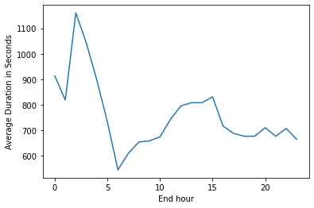

```python
end_df = df2[['duration_sec','end_hour']]
hour_means = end_df.groupby('end_hour').mean()
hour_means = hour_means.reset_index()

plt.errorbar(data=hour_means, x='end_hour', y='duration_sec')
plt.xlabel('End hour');
plt.ylabel('Average Duration in Seconds');
```

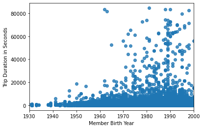

```python
# creat a scatter plot for the reltionship between birth year and duration
sb.regplot(data = df2, x = 'member_birth_year', y = 'duration_sec', fit_reg=False);
# set the limit of the x axis from 1930 to 2000
plt.xlim(1930,2000)
#set labels
plt.xlabel('Member Birth Year')
plt.ylabel('Trip Duration in Seconds');
```

As we can see from the scatter plot, there is a significant accumilation of data points within the 20000 second mark of the duration. Interestingly, we don't see trip durations higher than 20000 seconds for users who were born earlier than 1960. Consequentially, we see more outliers of duration for younger users. Now let's look into the mean duration for each age group.

```python
# set bins and bin centers
bin_edges = np.arange(1930, df2['member_birth_year'].max()+2, 2)
bin_centers = bin_edges[:-1] + 0.1

# Cut the bin values into discrete intervals
year_binned = pd.cut(df2['member_birth_year'], bin_edges, include_lowest = True)
```

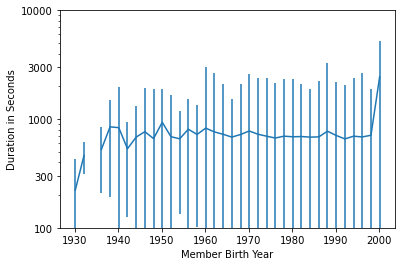

```python
dur_mean = df2['duration_sec'].groupby(year_binned).mean()
dur_std = df2['duration_sec'].groupby(year_binned).std()

ticks = [100, 300, 1000, 3000, 10000]

labels = ['{}'.format(v) for v in ticks]
# Plot the summarized data
plt.errorbar(x=bin_centers, y=dur_mean, yerr=dur_std)
# transform the duration to a log-type feature
plt.yscale('log')
#set ticks
plt.yticks(ticks,labels)
# set labels
plt.ylabel('Duration in Seconds');
plt.xlabel('Member Birth Year');
```

We can see from this line plot that the mean duration is the lowest for the older generations, However the standard deviation is relatively low. On the other hand, the younger generations have higher mean duration, with the highest mean duration for the 2000 generation. However the standard deviation is the highest. Now let's look into the effect of the user gender on the duration.

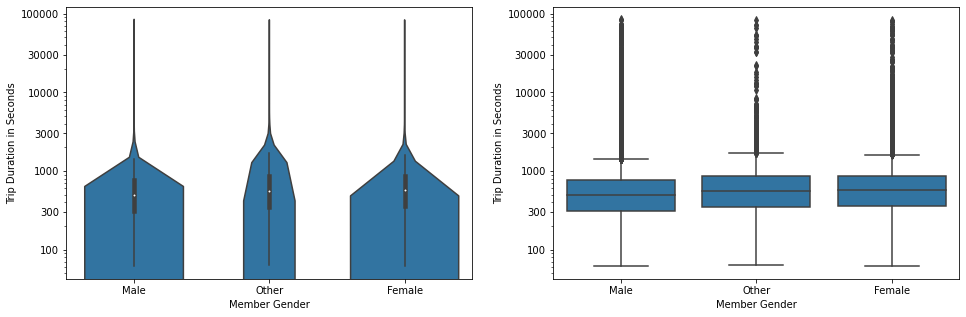

```python
# set figure size and base color
plt.figure(figsize = [16, 5])
base_color = sb.color_palette()[0]
# set ticks
ticks = [100, 300, 1000, 3000, 10000, 30000, 100000]

labels = ['{}'.format(v) for v in ticks]

# LEFT plot: violin plot
plt.subplot(1, 2, 1)

ax1 = sb.violinplot(data=df2, x='member_gender', y='duration_sec', color=base_color, innner='quartile');
plt.yscale('log')
plt.yticks(ticks,labels);
plt.xlabel('Member Gender');
plt.ylabel('Trip Duration in Seconds');

# RIGHT plot: box plot
plt.subplot(1, 2, 2)
sb.boxplot(data=df2, x='member_gender', y='duration_sec', color=base_color);
plt.yscale('log')
plt.yticks(ticks,labels)
plt.xlabel('Member Gender');
plt.ylabel('Trip Duration in Seconds');
# set y axis limits to be same as left plot
plt.ylim(ax1.get_ylim());
```

As we can see from both the violin and box plots, the median trip duration for all genders is almost identical, as well as the interquartile range. We can also see that there is a significant amount of outliers across all genders when it comes to trip duration. Now, let's look at the user type and its effect on trip duration.

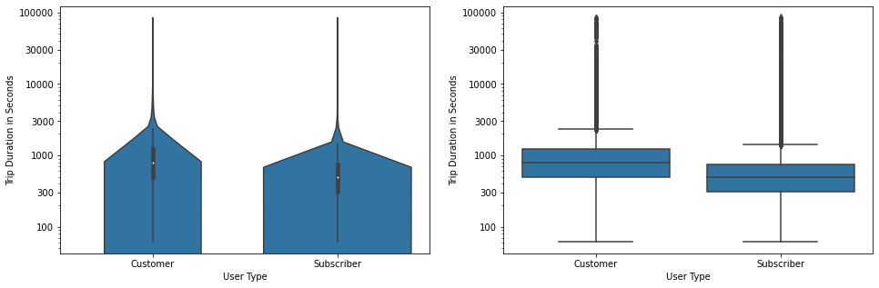

```python
plt.figure(figsize = [16, 5])

# LEFT plot: violin plot
plt.subplot(1, 2, 1)

ax1 = sb.violinplot(data=df2, x='user_type', y='duration_sec', color=base_color, innner='quartile');
plt.yscale('log')
plt.yticks(ticks,labels);
plt.xlabel('User Type');
plt.ylabel('Trip Duration in Seconds');


# RIGHT plot: box plot
plt.subplot(1, 2, 2)
sb.boxplot(data=df2, x='user_type', y='duration_sec', color=base_color);
plt.yscale('log')
plt.yticks(ticks,labels)
plt.xlabel('User Type');
plt.ylabel('Trip Duration in Seconds');
# set y axis limits to be same as left plot
plt.ylim(ax1.get_ylim());
```

There is a noticable difference in median trip duration customer type users and subscribing users. Customers seem to have a higher median trip duration, as well as the maximum trip duration value. However, both types have a significant amount of outliers reaching close to the 100000 second mark. Now let's look at the bike_share_for_all_trip column and how it relates to the user types.

```python
df['bike_share_for_all_trip']
```

```
0          No
2          No
3          No
4         Yes
5          No
         ...
183407     No
183408     No
183409    Yes
183410     No
183411     No
Name: bike_share_for_all_trip, Length: 174952, dtype: object
```

```python
# transform the values of the column to 1's and 0's
df2['bike_share_for_all_trip'] = df.bike_share_for_all_trip.map(dict(Yes=1, No=0))
df2['bike_share_for_all_trip']
```

```
0         0
2         0
3         0
4         1
5         0
         ..
183407    0
183408    0
183409    1
183410    0
183411    0
Name: bike_share_for_all_trip, Length: 174952, dtype: int64
```

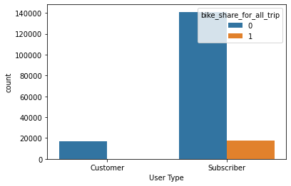

```python
# plot a clustered bar chart to visualize the relationship
sb.countplot(data = df2, x = 'user_type', hue = 'bike_share_for_all_trip');
plt.xlabel('User Type');
```

We can see from the clustered bar chart how only the subscribing users chose that option, and only a small proportion of them did.

### Did you observe any interesting relationships between the other features (not the main feature(s) of interest)?

We looked into the relationship between the bike share for all column and the user type column. we created a bar chart to highlight the relationship as both variables are categorical. The figure shows that the bike share for all was only true for a small portion of subscribers and no customers at all.

## Multivariate Exploration

> Create plots of three or more variables to investigate your data even further. Make sure that your investigations are justified, and follow from your work in the previous sections.

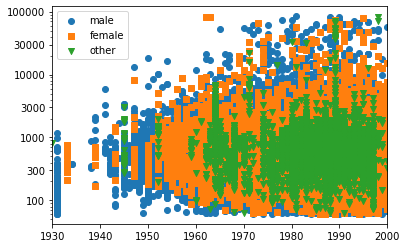

```python
# set markers
markers = [['Male', 'o'],
               ['Female', 's'],
               ['Other','v']]
# set ticks
ticks = [100, 300, 1000, 3000, 10000, 30000, 100000]

labels = ['{}'.format(v) for v in ticks]
# iterate over data points to apply markers
for gen, marker in markers:
    df_gen = df2[df2['member_gender'] == gen]
    plt.scatter(data = df_gen, x = 'member_birth_year', y = 'duration_sec', marker = marker)
    plt.xlim(1930,2000)

    plt.yscale('log')# scaale to log-type

plt.yticks(ticks,labels);
# set legend
plt.legend(['male','female','other']);
```

We can see from the figure the difference in the accumulation of data points across genders, with the outliers for the older generations mostly belonging to males. However, a deeper look is needed to see if the gender has an effect accross different generations on the mean duration.

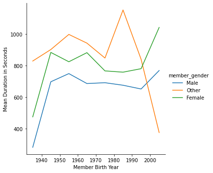

```python
# creat a function to creat a line plot
def mean_poly(x, y, bins = 5, **kwargs):
    # set bin edges if none or int specified
    if type(bins) == int:
        bins = np.linspace(x.min(), x.max(), bins+1)
    bin_centers = (bin_edges[1:] + bin_edges[:-1]) / 2

    # compute counts
    data_bins = pd.cut(x, bins, right = False,
                       include_lowest = True)
    means = y.groupby(data_bins).mean()

    # plot the data
    plt.errorbar(x = bin_centers, y = means, **kwargs)

bin_edges = np.arange(1930, df2['member_birth_year'].max()+10, 10)
g = sb.FacetGrid(data = df2, hue = 'member_gender', size = 5)
g.map(mean_poly, "member_birth_year", "duration_sec", bins = bin_edges)
g.set_ylabels('Mean Duration in Seconds')
g.set_xlabels('Member Birth Year')
g.add_legend();
```

For the figure above, we can see clearly how the 'other' gender has a highest mean durations accross different generations with a peak for the users born around 1990. However, it takes a steep drop afterwards till it reaches its lowest level for the users born on 2000 and after. On the other hand, males and females relatively follow the same trend with a rise in the mid 1940's and continue to reach the highest mean duration after the mid 1990's. Finally, we can see a higher variance in the 'other' gender' accross generations, so let's investigate this even further while looking accross user types.

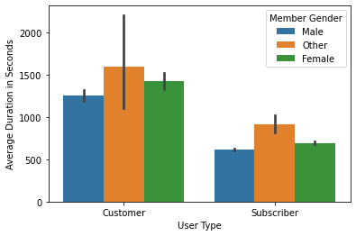

```python
# creat clustered bar plot instance
ax = sb.barplot(data = df2, x = 'user_type', y = 'duration_sec', hue = 'member_gender')
#set legend
ax.legend(loc = 1, title = 'Member Gender');
#set labels
plt.xlabel('User Type')
plt.ylabel('Average Duration in Seconds');
```

As we saw earlier, Customers have a higher mean trip duration, but now we can see this is true across all genders. However, when it comes to customers from the 'other' gender have a significantly higher standard deviation than all other categories of users. Now let's look into the effect of the start hour of the trip and the duration across genders.

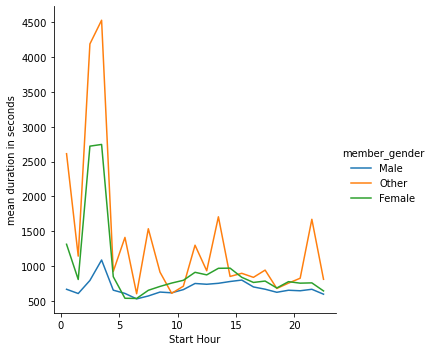

```python
# set bins for the hours
bin_edges = np.arange(0, df2['start_hour'].max()+1, 1)
# creat plot instance
g = sb.FacetGrid(data = df2, hue = 'member_gender', size = 5)
g.map(mean_poly, "start_hour", "duration_sec", bins = bin_edges)
# set labels
g.set_xlabels('Start Hour')
g.set_ylabels('mean duration in seconds')
# set the legend
g.add_legend();
```

From this plot we can observe how the 'other' gender has a significantly high mean trip duration for the trips that start at the early hours of the morning, more so than other genders. We can also see the higher variance across the line plot for the 'other' gender. Now we'll look into the relationship between the trip start hour and the mean duration accross different user types.

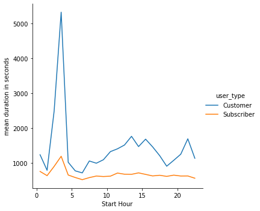

```python
# set bins for the hours
bin_edges = np.arange(0, df2['start_hour'].max()+1, 1)
# creat plot instance
g = sb.FacetGrid(data = df2, hue = 'user_type', size = 5)
g.map(mean_poly, "start_hour", "duration_sec", bins = bin_edges)
# set labels
g.set_ylabels('mean duration in seconds')
g.set_xlabels('Start Hour')
# set the legend
g.add_legend();
```

As we can see from the line plot above, customers who had their trip start hour around 3 AM had the highest mean trip duration, reaching beyond 5000 seconds; all while having higher variance across all hours of the day. On the other hand, subscribers had lower variance and lower overall mean trip duration. Next, we will look into the effect of the trip end hour on the mean trip duration across genders.

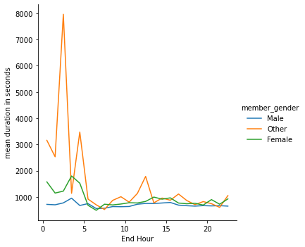

```python
# set bins for the hours
bin_edges = np.arange(0, df2['end_hour'].max()+1, 1)
# creat plot instance
g = sb.FacetGrid(data = df2, hue = 'member_gender', size = 5)
g.map(mean_poly, "end_hour", "duration_sec", bins = bin_edges)
# set labels
g.set_ylabels('mean duration in seconds')
g.set_xlabels('End Hour')
# set the legend
g.add_legend();
```

As we can see from the line plot above, the 'other' gender has the highest variance across all hours of the day in terms of trip end hours; as well as having the highest overall mean trip duration with a peak for trips ending at the earlier hours of the morning, reaching as high as 8000 seconds. On the other hand, we can see a lower variance for both males and females across all hours of the day with peaks around the early hours of the morning as well. Next, we are going to look at the effect of end hours on the mean trip duration across all user types.

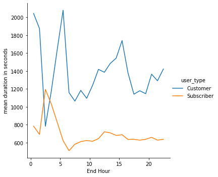

```python
# set bins for the hours
bin_edges = np.arange(0, df2['end_hour'].max()+1, 1)
# creat plot instance
g = sb.FacetGrid(data = df2, hue = 'user_type', size = 5)
g.map(mean_poly, "end_hour", "duration_sec", bins = bin_edges)
# set labels
g.set_ylabels('mean duration in seconds')
g.set_xlabels('End Hour')
# set the legend
g.add_legend();
```

From the plot above we can observe the higher variance of the customer type users across all hours of the day, with peaks at varying hours, reaching further than 2000 seconds. On the other hand, we can see lower variance for subscribers, with one peak around 2 AM, reaching up to 1200 seconds, contradictorily to that of the customer type users, that has its steepest fall around the same hour.

### Talk about some of the relationships you observed in this part of the investigation. Were there features that strengthened each other in terms of looking at your feature(s) of interest?

First, we started looking at the distribution of trip durations across all genders in terms of birth year. So we plotted a scatter plot depicting the three variables. The plot was not as insightful as we hoped, so we created a line plot depicting the mean trip duration for each gender throughout the birth years. The line plot showed that males had the overall lowest mean trip duration throughout the generations. While the users who chose 'other' as gender were the highest in overall mean trip duration. however the plot showed a steep decline of the mean trip duration for the 'other' gender for users who were born after the mid 1980's, to reach its lowest point for users born in 2000. Secondly, we looked at the relationship between the trip duration and user type across all genders. We created a clustered bar chart to depict all three variables. We can infer from the chart that the mean duration for customers is higher than that of the subscribers across all gender, with the observation that the standard deviation of the 'other' gender in customers is the highest. Afterwards we looked at the start and end hours and their relationship with the duration across genders and user types. We used a line plot to visualize these relationships. The plots show in more detail the variance of the trip duration throughout the hours of the day, and how different genders and different user types have different trends when it comes to start and end hours as well as trip duration.

### Were there any interesting or surprising interactions between features?

The most interesting observation throughout this part of the investigation is how variant the trip duration for two categories of users, the 'customers' and the 'other' gender. We can see accross different age groups and different start and end hours how the trip duration varies significantly. This would also explain the the noticable amount of outliers we've seen in the bivariate exploration.